# Apurva Mahajan - Detroit

2025-06-04

## Story pitch:

I’m analyzing the percentage change in childhood vaccination rates in Michigan by county across the past decade, with a focus on measles as Michigan continues to see [more cases of the disease](https://www.detroitnews.com/story/news/local/michigan/2025/06/04/measles-cases-confirmed-in-marquette-county/84028433007/).

I plan on creating a choropleth map in Datawrapper/Flourish to show the changes in vaccine rates over time for infants and teenagers, respectively. I have initial graphics using ggplot, but because my angle changed in the middle of the day Wednesday after my correlation coefficient analysis resulted in little correlation, I was unfortunately unable to complete a polished graphic that I can embed, but plan on doing so tomorrow.

I performed a correlation coefficient analysis on both the percent change in election results (percentage point difference between parties) and the percentage change in the vaccination rates for each of the two series for children and teenagers, respectively, and found that there was little correlation. I also performed the same analysis on aggregated vaccine series data and election results for each election year and found that there was also no significant correlation here. Because of this, I’m moving away from the angle of looking at election results to see if counties that vote more Republican line up with a drop in vaccination rates across counties. Instead, I’m shifting my angle to just look at overall changes in vaccination based on the vaccination report card data, to determine the counties that have dropped the most in their recommended vaccination coverage for children and teenagers.

I initially tried to aggregate the four vaccine series, but I do not think that is the best method to go about this analysis, as they cover different age ranges. Instead, I’m aggregating the vaccine rates based on the age range that is recommended to get them — two of the series are specifically for children aged 19 months to 35 months, and the two others are recommended for adolescents aged 13 to 17.

###### Old portion of pitch, outdated

I’ve joined the vaccination report card data to Census ACS data from 2023 on population for each county, and am working on joining election data to this to see if there’s a pattern between vaccination rates and how people voted in the 2024 and 2016 elections. I’d like to see the proportion of votes allocated toward the Republican Party and the Democratic Party for each of the counties in Michigan, and I want to perform a more robust analysis for these counties beyond what I found of the two counties that immediately stand out. I also plan on looking at the vaccination rates for the MMR vaccine alone. I’ve found the csv for this from the Michigan government and will load it in as I continue work on this story. The measles vaccine, which is included in each of the four vaccine series I’m analyzing, is primarily administered to young children and adolescents. There have been 9 reported measles cases this year in Michigan so far, in Ingham, Kent, Macomb, Marquette, Montcalm and Oakland Counties, making this the worst year in decades for measles in Michigan.

# Load software libraries

```r
#install.packages("tidyverse")
#install.packages("janitor")
#install.packages("readxl")
#install.packages("tidycensus")
#install.packages("DT")
library(tidyverse)
library(janitor)
library(readxl)
library(tidycensus)
library(DT)
library(sf)
library(gridExtra)
library(zoo)
```

# Load data + initial cleaning

```r
# The report card data provides estimates for immunization coverage at the county level for vaccines recommended for children (19-35 months) and adolescent (13-17-year-olds).
# Load vaccine report card data.
report_card_data <- read.csv("../data/Report_card_All_data_20250313.csv") |>
    clean_names()

# Load geoJSON for mapping.
mi_counties <- read_sf("../data/County.geojson") %>% clean_names()


# How many counties?
report_card_data$cntyname %>%
  unique()
```

```
##  [1] "Alcona"         "Alger"          "Allegan"        "Alpena"
##  [5] "Antrim"         "Arenac"         "Baraga"         "Barry"
##  [9] "Bay"            "Benzie"         "Berrien"        "Branch"
## [13] "Calhoun"        "Cass"           "Charlevoix"     "Cheboygan"
## [17] "Chippewa"       "Clare"          "Clinton"        "Crawford"
## [21] "Delta"          "Detroit"        "Dickinson"      "Eaton"
## [25] "Emmet"          "Genesee"        "Gladwin"        "Gogebic"
## [29] "Grand Traverse" "Gratiot"        "Hillsdale"      "Houghton"
## [33] "Huron"          "Ingham"         "Ionia"          "Iosco"
## [37] "Iron"           "Isabella"       "Jackson"        "Kalamazoo"
## [41] "Kalkaska"       "Kent"           "Keweenaw"       "Lake"
## [45] "Lapeer"         "Leelanau"       "Lenawee"        "Livingston"
## [49] "Luce"           "Mackinac"       "Macomb"         "Manistee"
## [53] "Marquette"      "Mason"          "Mecosta"        "Menominee"
## [57] "Michigan"       "Midland"        "Missaukee"      "Monroe"
## [61] "Montcalm"       "Montmorency"    "Muskegon"       "Newaygo"
## [65] "Oakland"        "Oceana"         "Ogemaw"         "Ontonagon"
## [69] "Osceola"        "Oscoda"         "Otsego"         "Ottawa"
## [73] "Presque Isle"   "Roscommon"      "Saginaw"        "Sanilac"
## [77] "Schoolcraft"    "Shiawassee"     "St. Clair"      "St. Joseph"
## [81] "Tuscola"        "Van Buren"      "Washtenaw"      "Wayne"
## [85] "Wexford"
```

```r
# Michigan has 83 counties. There are 85 unique county values, because this data set includes Detroit City and the State of Michigan's vaccination report cards.
# I'm creating a column based on an index so I can plot this and analyze by time.
report_card_data <- report_card_data %>%
  mutate(
     quarter_num = as.numeric(sub("Q", "", quarter)),
     quarter_index = year + (quarter_num - 1) / 4,
    quarter_date = make_date(year, (quarter_num - 1) * 3 + 1, 1)
  )
```

# Percent change analysis for four childhood vaccination series over the past decade

```r
### PERCENT CHANGE IN VACCINATION COVERAGE

# For this analysis, I'm focusing on the vaccine series 4313314, 43133142, 132321, 1323213, and the MMR vaccine. These are the series Michigan recommends for children and adolescents — the first two are for babies from 19-35 months, and the latter two are for teens.
```

## 4313314 series:

- 4 or more doses of DTaP/DTP/DT
- 3 or more doses of Polio
- 1 or more dose of MMR
- 3 or more doses of Hib
- 3 or more doses of HepB
- 1 or more dose of Varicella
- 4 or more doses of PCV.

```r
# Let's look at the 4313314 series: "4 or more doses of DTaP/DTP/DT, 3 or more doses of Polio, 1 or more dose of MMR, 3 or more doses of Hib, 3 ore more doses of HepB, 1 or more dose of Varicella, 4 or more doses of PCV."
# Coverage for the 4313314 vaccine decreased for all but three counties in Michigan. Oscoda and Keweenaw Counties nearly halved their vaccine coverage for this series.

series_1 <- report_card_data %>%
  group_by(cntyname) %>%
  filter(quarter_index %in% c(2014.75, 2024.75)) %>%
  select(cntyname, quarter_index, covg4313314) %>%
  pivot_wider(
    names_from = quarter_index,
    values_from = covg4313314,
    names_prefix = "Q_"
  ) %>%
  mutate(pct_change_2014_2024 = 100 * (Q_2024.75 - Q_2014.75) / Q_2014.75) %>%
  arrange(pct_change_2014_2024)

datatable(series_1, options = list(pageLength = 10))
```

|  | cntyname | Q_2014.75 | Q_2024.75 | pct_change_2014_2024 |
| --- | --- | --- | --- | --- |
| 1 | Oscoda | 71.4 | 37.7 | -47.19887955182073 |
| 2 | Keweenaw | 73.7 | 39.1 | -46.94708276797829 |
| 3 | Branch | 80.4 | 56.8 | -29.35323383084578 |
| 4 | Gladwin | 79.8 | 56.5 | -29.19799498746867 |
| 5 | Osceola | 82.4 | 59.4 | -27.91262135922331 |
| 6 | Sanilac | 74.8 | 55.1 | -26.33689839572192 |
| 7 | Mackinac | 76.7 | 57 | -25.68448500651891 |
| 8 | Hillsdale | 78.3 | 58.9 | -24.7765006385696 |
| 9 | Lake | 75.3 | 57.1 | -24.16998671978751 |
| 10 | St. Joseph | 81.5 | 61.9 | -24.04907975460123 |

[output cut: 75 more lines]

## 43133142 series:

- 4 or more doses of DTaP/DTP/DT
- 3 or more doses of Polio
- 1 or more dose of MMR
- 3 or more doses of Hib
- 3 or more doses of Hep B
- 1 or more dose of Varicella
- 4 or more doses of PCV
- 2 or more doses of HepA

```r
## Again, Oscoda and Keweenaw are in the top two counties that have nearly halved their vaccine coverage for this series.
series_2 <- report_card_data %>%
  group_by(cntyname) %>%
  filter(quarter_index %in% c(2014.75, 2024.75)) %>%
  select(cntyname, quarter_index, covg43133142) %>%
  pivot_wider(
    names_from = quarter_index,
    values_from = covg43133142,
    names_prefix = "Q_"
  ) %>%
  mutate(pct_change_2014_2024 = 100 * (Q_2024.75 - Q_2014.75) / Q_2014.75) %>%
  arrange(pct_change_2014_2024)

datatable(series_2, options = list(pageLength = 10))
```

|  | cntyname | Q_2014.75 | Q_2024.75 | pct_change_2014_2024 |
| --- | --- | --- | --- | --- |
| 1 | Keweenaw | 68.4 | 34.8 | -49.12280701754387 |
| 2 | Oscoda | 56.2 | 30.2 | -46.26334519572954 |
| 3 | Gladwin | 64.8 | 49.7 | -23.30246913580246 |
| 4 | Gogebic | 63.9 | 50.7 | -20.65727699530516 |
| 5 | Osceola | 61.3 | 49.4 | -19.41272430668841 |
| 6 | Lake | 52.9 | 43.8 | -17.20226843100189 |
| 7 | Houghton | 51.2 | 45.2 | -11.71875 |
| 8 | Mecosta | 62.7 | 55.5 | -11.48325358851675 |
| 9 | Baraga | 55.4 | 50.4 | -9.025270758122744 |
| 10 | Huron | 54.6 | 50.6 | -7.326007326007326 |

[output cut: 75 more lines]

## 132321 series:

- 1 or more doses of Tdap
- 3 or more doses of Polio
- 2 or more doses of MMR
- 3 or more doses of HepB
- 2 or more doses of Varicella
- 1 or more dose of MenACWY

```r
# This series did not have as high percent change decreases, but Keewenaw is in the top five here too.
series_3 <- report_card_data %>%
  group_by(cntyname) %>%
  filter(quarter_index %in% c(2014.75, 2024.75)) %>%
  select(cntyname, quarter_index, covg132321) %>%
  pivot_wider(
    names_from = quarter_index,
    values_from = covg132321,
    names_prefix = "Q_"
  ) %>%
  mutate(pct_change_2014_2024 = 100 * (Q_2024.75 - Q_2014.75) / Q_2014.75) %>%
  arrange(pct_change_2014_2024)

datatable(series_3, options = list(pageLength = 10))
```

|  | cntyname | Q_2014.75 | Q_2024.75 | pct_change_2014_2024 |
| --- | --- | --- | --- | --- |
| 1 | Iron | 77.2 | 69.9 | -9.455958549222794 |
| 2 | Luce | 80.3 | 73.1 | -8.966376089663765 |
| 3 | Keweenaw | 67.9 | 63 | -7.216494845360833 |
| 4 | Calhoun | 79 | 73.4 | -7.088607594936701 |
| 5 | Schoolcraft | 82.8 | 77.2 | -6.763285024154583 |
| 6 | Kalamazoo | 77.8 | 72.8 | -6.426735218508997 |
| 7 | Cass | 65 | 61.3 | -5.692307692307697 |
| 8 | Missaukee | 78.8 | 75.1 | -4.695431472081222 |
| 9 | Muskegon | 81.6 | 77.9 | -4.534313725490183 |
| 10 | Monroe | 66.5 | 63.8 | -4.060150375939854 |

[output cut: 75 more lines]

## 1323213 series:

- 1 or more doses of Tdap
- 3 or more doses of Polio
- 2 or more doses of MMR
- 3 or more doses of HepB
- 2 or more doses of Varicella
- 1 or more dose of MenACWY
- HPV complete (with 2 or 3 doses (Males & Females))

```r
# Nearly all counties have increased their coverage of this series. I'm wondering the reason behind this, and if it is significant. Could this change be because this is a new vaccine series that only started being implemented recently? Would love to talk to a Michigan epidemiologist who works for the state DHHS or some other expert to understand this.
series_4 <- report_card_data %>%
  group_by(cntyname) %>%
  filter(quarter_index %in% c(2014.75, 2024.75)) %>%
  select(cntyname, quarter_index, covg1323213) %>%
  pivot_wider(
    names_from = quarter_index,
    values_from = covg1323213,
    names_prefix = "Q_"
  ) %>%
  mutate(pct_change_2014_2024 = 100 * (Q_2024.75 - Q_2014.75) / Q_2014.75) %>%
  arrange(pct_change_2014_2024)

datatable(series_4, options = list(pageLength = 10))
```

|  | cntyname | Q_2014.75 | Q_2024.75 | pct_change_2014_2024 |
| --- | --- | --- | --- | --- |
| 1 | Mackinac | 31.1 | 27.1 | -12.86173633440514 |
| 2 | Gogebic | 28.8 | 33.2 | 15.27777777777779 |
| 3 | Chippewa | 31.7 | 37.9 | 19.5583596214511 |
| 4 | Crawford | 37.7 | 46 | 22.01591511936339 |
| 5 | Hillsdale | 28.9 | 35.4 | 22.49134948096886 |
| 6 | Baraga | 30.3 | 37.3 | 23.10231023102309 |
| 7 | Montmorency | 33.8 | 42.8 | 26.62721893491124 |
| 8 | Huron | 31 | 39.9 | 28.70967741935484 |
| 9 | Kalkaska | 32.5 | 42.4 | 30.46153846153846 |
| 10 | Keweenaw | 18.3 | 24 | 31.14754098360655 |

[output cut: 75 more lines]

# Analysis by age of series

### The 431XXXX series are administered to children 19-35 months, while the 132XXXX series are for adolescents aged 13-17 years. Let’s do an unweighted mean of vaccination rates by the age range of the vaccine series instead of aggregating all four.

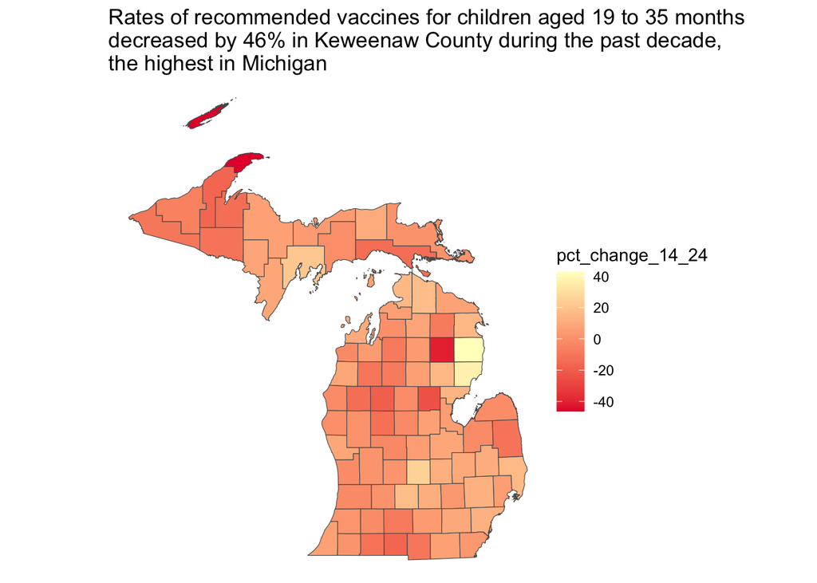

```r
# Aggregating vaccine rates for just the infant series.
baby_vax <- report_card_data %>%
  mutate(vax_agg = ((covg4313314 + covg43133142)/2)) %>%
  select(cntyname, year, vax_agg) %>%
  group_by(cntyname, year) %>%
  summarize(mean_vax_rate = mean(vax_agg, na.rm = TRUE))

# Infant vaccine series rate over past decade.
baby_vax_change <- baby_vax %>%
  pivot_wider(
    names_from = year,
    values_from = mean_vax_rate,
    names_prefix = "Y_"
  ) %>%
  mutate(
    pct_change_14_24 = ((Y_2024 - Y_2014)/Y_2014) * 100
  ) %>%
  select(cntyname, pct_change_14_24) %>%
  arrange(pct_change_14_24)

# Mapping percentage change of vaccination rates for infants.
mi_counties %>%
  inner_join(baby_vax_change, by = c("name" = "cntyname")) %>%
  ggplot() +
  geom_sf(aes(fill = pct_change_14_24)) +
  scale_fill_gradient(
    high = "#FFFFC5",
    low = "#e51d37") +
  labs(title = "Rates of recommended vaccines for children aged 19 to 35 months
decreased by 46% in Keweenaw County during the past decade,
the highest in Michigan") +
  theme_void()
```

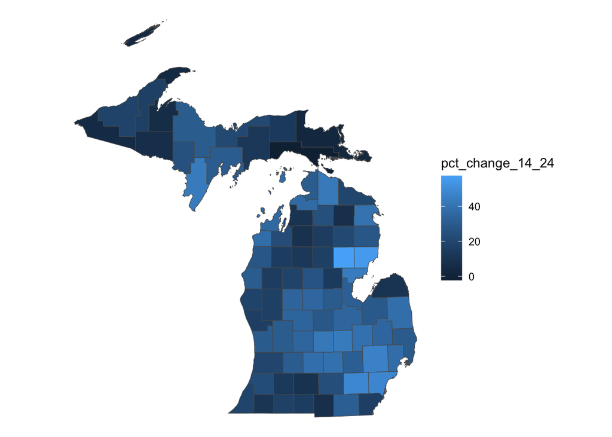

```r
# Aggregating vaccine rates for just the adolescent series.
teen_vax <- report_card_data %>%
  mutate(vax_agg = ((covg132321 + covg1323213)/2)) %>%
  select(cntyname, year, vax_agg) %>%
  group_by(cntyname, year) %>%
  summarize(mean_vax_rate = mean(vax_agg, na.rm = TRUE))

# Adolescent vaccine rate over past decade.
# The vaccine rate for the teen series has increased in nearly every county in the past ten years, primarily because of the 1323213 series, which saw an increase in nearly every county as well. I wonder if this could be because it's a newer series that only recently began to be implemented, but I need to talk to an expert about this.
teen_vax_change <- teen_vax %>%
  pivot_wider(
    names_from = year,
    values_from = mean_vax_rate,
    names_prefix = "Y_"
  ) %>%
  mutate(
    pct_change_14_24 = ((Y_2024 - Y_2014)/Y_2014) * 100
  ) %>%
  select(cntyname, pct_change_14_24) %>%
  arrange(pct_change_14_24)

# Mapping percentage change of teenage vaccination series from 2014 to 2024.
mi_counties %>%
  inner_join(teen_vax_change, by = c("name" = "cntyname")) %>%
  ggplot() +
  geom_sf(aes(fill = pct_change_14_24)) +
  theme_void()
```

# MMR vaccine data: 19-35 months.

##### The MMR vaccine’s coverage rate in young children has decreased by 6.8% since January 2020.

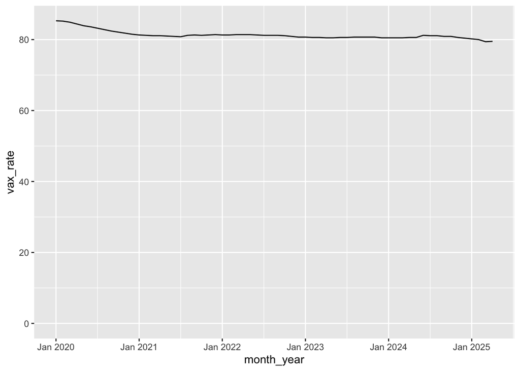

```r
infant_vax_2020_25 <- read_excel("../data/mcir-vax-data/Profile-by-County-19-35-Months-2020-Present.xlsx", sheet = 2) %>% clean_names

# Filtering the statewide MMR vaccine rates for Michigan.
infant_mmr_2020_25 <- infant_vax_2020_25 %>%
  filter(antigen == "1+ MMR") %>%
  pivot_longer(
    cols = jan2020:apr2025,
    names_to = "month",
    values_to = "vax_rate"
  ) %>%
  mutate(month_year = as.yearmon(month, format = "%b%Y")) %>%
  select(-month)

# Plotting change over time.
infant_mmr_2020_25 %>%
  ggplot() +
  geom_line(aes(x=month_year, y = vax_rate)) +
  expand_limits(y=0)
```

```r
# Percent change from January 2020 to April 2025.
100 * ((79.5-85.3)/85.3)
```

```
## [1] -6.799531
```

# MMR vaccine data: 13-17 years. (Data is only available for May 2024 to April 2025)

#### MMR vaccine rates for teenagers has stayed relatively the same in the past year, increasing by 0.23% in that time.

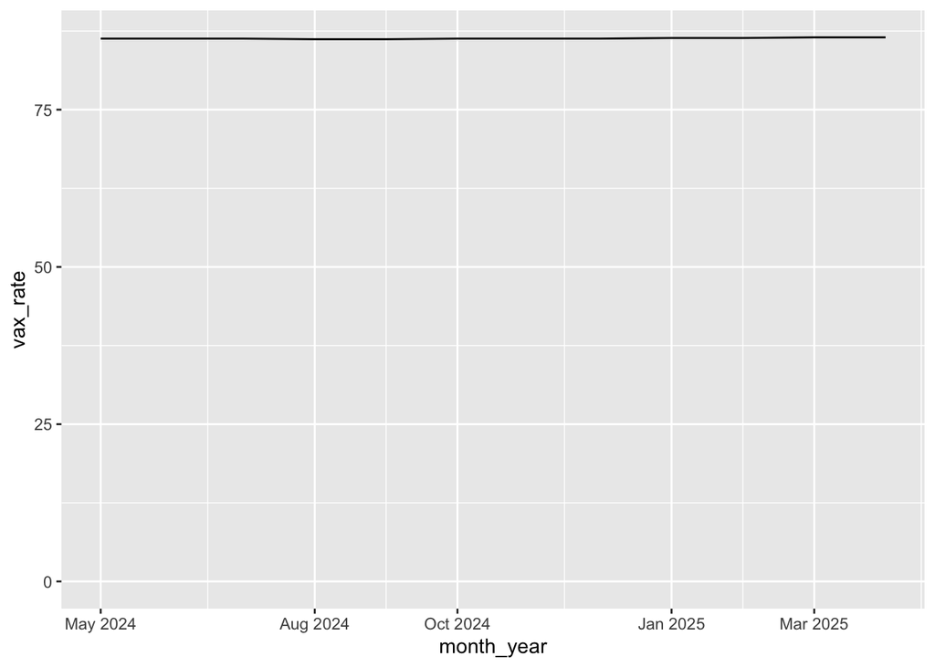

```r
# Filtering just statewide MMR vaccine data for adolescents.
teen_mmr_2020_25 <- read_excel("../data/mcir-vax-data/Profile-by-County-13-17-Years-2020-Present.xlsx", sheet = 2) %>% clean_names %>%
  filter(antigen == "2+ MMR") %>%
  pivot_longer(
    cols = may2024:apr2025,
    names_to = "month",
    values_to = "vax_rate"
  ) %>%
  mutate(month_year = as.yearmon(month, format = "%b%Y")) %>%
  select(-month)

teen_mmr_2020_25 %>%
  ggplot() +
  geom_line(aes(x=month_year, y = vax_rate)) +
  expand_limits(y=0)
```

```r
100 * ((86.5-86.3)/86.3)
```

```
## [1] 0.2317497
```

# Aggregated analysis

```r
# I'm focusing on the vaccine series 4313314, 43133142, 132321, 1323213, and the MMR vaccine. These are the series Michigan recommends for children and adolescents.

# Create a column that has an unweighted average of all four of these series. Also group by year instead of quarter to more easily see yearly changes.
report_card_data_aggregated <- report_card_data %>%
  mutate(series_agg = (covg4313314 + covg43133142 + covg132321 + covg1323213)/4) %>%
  select(cntyname, quarter_index, quarter_date, series_agg) %>%
  mutate(year = floor(quarter_index)) %>%
  group_by(cntyname, year) %>%
  summarize(mean_vax_rate = mean(series_agg, na.rm = TRUE))
```

```r
# report_card_data_aggregated %>%
  # filter(cntyname == "Keweenaw") %>%
  # ggplot(aes(x=year)) +
  # geom_line(aes(y = mean_vax_rate)) +
  # labs(title = "Coverage Over Time in Keweenaw County",
      # y = "Coverage Value",
      # x = "Quarter",
      # color = "Coverage Type") +
  # theme_minimal()

# Ten-year percent change for aggregated vaccine series.
pct_change_agg <- report_card_data_aggregated %>%
  group_by(cntyname) %>%
  pivot_wider(
    names_from = year,
    values_from = mean_vax_rate,
    names_prefix = "Y_"
  ) %>%
   mutate(pct_change_2014_2024 = 100 * (Y_2024 - Y_2014) / Y_2014) %>%
  select(cntyname, pct_change_2014_2024) %>%
  arrange(pct_change_2014_2024)
```

# Population analysis

```r
# Let's look at populations for these counties.
# Load 2023 ACS population data from tidycensus.
vars <- load_variables(2023, "acs1")

# 2023 Census population by county.
pop_by_county <- get_acs(
  geography = "county",
  variables = "B01001A_001",
  state = "MI",
) %>% clean_names()

# Cleaning census data set's names to get rid of extra text like "County."
pop_by_county$name <- sub(" County.*", "", pop_by_county$name)

report_card_with_pop <- report_card_data %>%
  inner_join(pop_by_county, join_by(cntyname == name)) %>%
  select(
    cntyname, quarter_index, covg4313314, covg43133142, covg132321, covg1323213, estimate
  )

# Keewenaw is the county with the smallest population, with 2,021 people.
report_card_with_pop %>%
  filter(quarter_index == "2023.75") %>%
  group_by(cntyname) %>%
  arrange(estimate)
```

```
## # A tibble: 83 × 7
## # Groups:   cntyname [83]
##    cntyname    quarter_index covg4313314 covg43133142 covg132321 covg1323213
##    <chr>               <dbl>       <dbl>        <dbl>      <dbl>       <dbl>
##  1 Keweenaw            2024.        43.8         37.5       67.7        26.3
##  2 Luce                2024.        72.1         50         76.5        46.7
##  3 Ontonagon           2024.        68.9         66.7       76.4        41.5
##  4 Baraga              2024.        63.6         54.5       77.6        38.5
##  5 Schoolcraft         2024.        76.8         65.3       78.8        52.4
##  6 Alger               2024.        67           59.1       71.9        40.1
##  7 Mackinac            2024.        61           44.8       73.4        27.3
##  8 Oscoda              2024.        43           29.9       59.5        25.2
##  9 Montmorency         2024.        64.3         46         76.8        43
## 10 Alcona              2024.        69.6         54.9       73.5        55.1
## # ℹ 73 more rows
## # ℹ 1 more variable: estimate <dbl>
```

```r
# report_card_data %>%
#   filter(cntyname == "Keweenaw") %>%
#   ggplot(aes(x=quarter_index)) +
#   geom_line(aes(y = covg4313314, color = "covg4313314")) +
#   geom_line(aes(y = covg43133142, color = "covg43133142")) +
#   geom_line(aes(y = covg132321, color = "covg132321")) +
#   geom_line(aes(y = covg1323213, color = "covg1323213")) +
#   labs(title = "Coverage Over Time in Keweenaw County",
#        y = "Coverage Value",
#        x = "Quarter",
#        color = "Coverage Type") +
#   theme_minimal()
```

# Aggregate election analysis

```r
election_16 <- read.csv("../data/2016_US_County_Level_Presidential_Results.csv") %>%  clean_names()
election_20 <- read.csv("../data/2020_US_County_Level_Presidential_Results.csv") %>% clean_names()
election_24 <- read.csv("../data/2024_US_County_Level_Presidential_Results.csv") %>% clean_names()

# Filtering for just Michigan counties
mi_election_16 <- election_16 %>%
  filter(state_abbr == "MI")
mi_election_20 <- election_20 %>%
  filter(state_name == "Michigan")
mi_election_24 <- election_24 %>%
  filter(state_name == "Michigan")

# cleaning the names so they don't have "County" appended, since we're joining based on name
mi_election_16$county_name <- sub(" County.*", "", mi_election_16$county_name)
mi_election_20$county_name <- sub(" County.*", "", mi_election_20$county_name)
mi_election_24$county_name <- sub(" County.*", "", mi_election_24$county_name)

# Let's look at the average vaccine coverage by county in just election years.
vaccine_election_2016 <- report_card_data_aggregated %>%
  filter(year == 2016) %>%
  group_by(cntyname) %>%
  pivot_wider(
    names_from = year,
    values_from = mean_vax_rate,
    names_prefix = "Y_"
  ) %>%
  inner_join(mi_election_16, by = c("cntyname" = "county_name")) %>%
  select(cntyname, Y_2016, total_votes, per_dem, per_gop) %>%
  mutate(
    per_point_diff = (per_gop - per_dem)
  )

vaccine_election_2020 <- report_card_data_aggregated %>%
  filter(year == 2020) %>%
  group_by(cntyname) %>%
  pivot_wider(
    names_from = year,
    values_from = mean_vax_rate,
    names_prefix = "Y_"
  ) %>%
  inner_join(mi_election_20, by = c("cntyname" = "county_name")) %>%
  select(cntyname, Y_2020, total_votes, per_dem, per_gop, per_point_diff)

vaccine_election_2024 <- report_card_data_aggregated %>%
  filter(year == 2024) %>%
  group_by(cntyname) %>%
  pivot_wider(
    names_from = year,
    values_from = mean_vax_rate,
    names_prefix = "Y_"
  ) %>%
  inner_join(mi_election_24, by = c("cntyname" = "county_name")) %>%
  select(cntyname, Y_2024, total_votes, per_dem, per_gop, per_point_diff)
```

# Mapping election and vaccine results for 2024

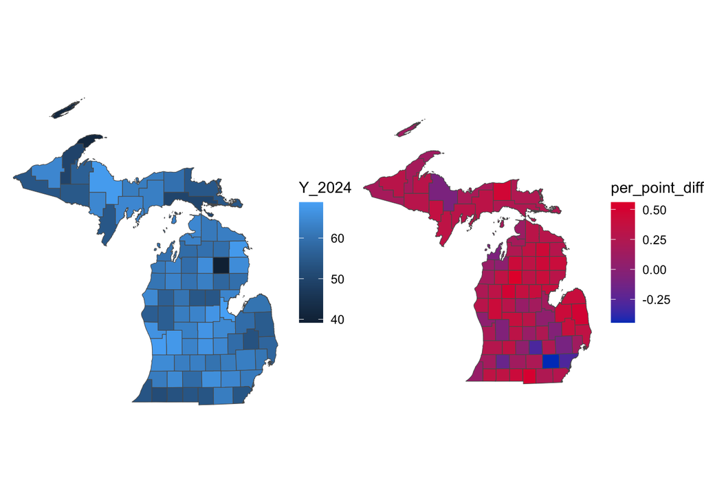

```r
# Plotting elections + vaccine results using a geoJSON of Michigan counties
# install.packages("gridExtra")

# joining geoJSON to aggregate childhood vaccination data
vaccines_24 <- mi_counties %>%
  inner_join(vaccine_election_2024, by = c("name" = "cntyname")) %>%
  ggplot() +
  geom_sf(aes(fill = Y_2024)) +
  theme_void()

mi_election_map_24 <- mi_counties %>%
  inner_join(vaccine_election_2024, by = c("name" = "cntyname")) %>%
  ggplot() +
  geom_sf(aes(fill = per_point_diff)) +
  scale_fill_gradient(
    low = "#0041C2",
    high = "#e51d37"
  ) +
  theme_void()

grid.arrange(vaccines_24, mi_election_map_24, ncol = 2)
```

# Election and vaccine rates in 2020

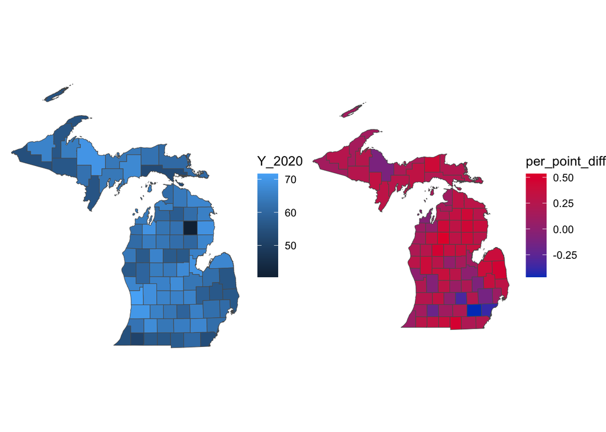

```r
vaccines_20 <- mi_counties %>%
  inner_join(vaccine_election_2020, by = c("name" = "cntyname")) %>%
  ggplot() +
  geom_sf(aes(fill = Y_2020)) +
  theme_void()

mi_election_map_20 <- mi_counties %>%
  inner_join(vaccine_election_2020, by = c("name" = "cntyname")) %>%
  ggplot() +
  geom_sf(aes(fill = per_point_diff)) +
  scale_fill_gradient(
    low = "#0041C2",
    high = "#e51d37"
  ) +
  theme_void()

grid.arrange(vaccines_20, mi_election_map_20, ncol = 2)
```

# Election and vaccine rates in 2016

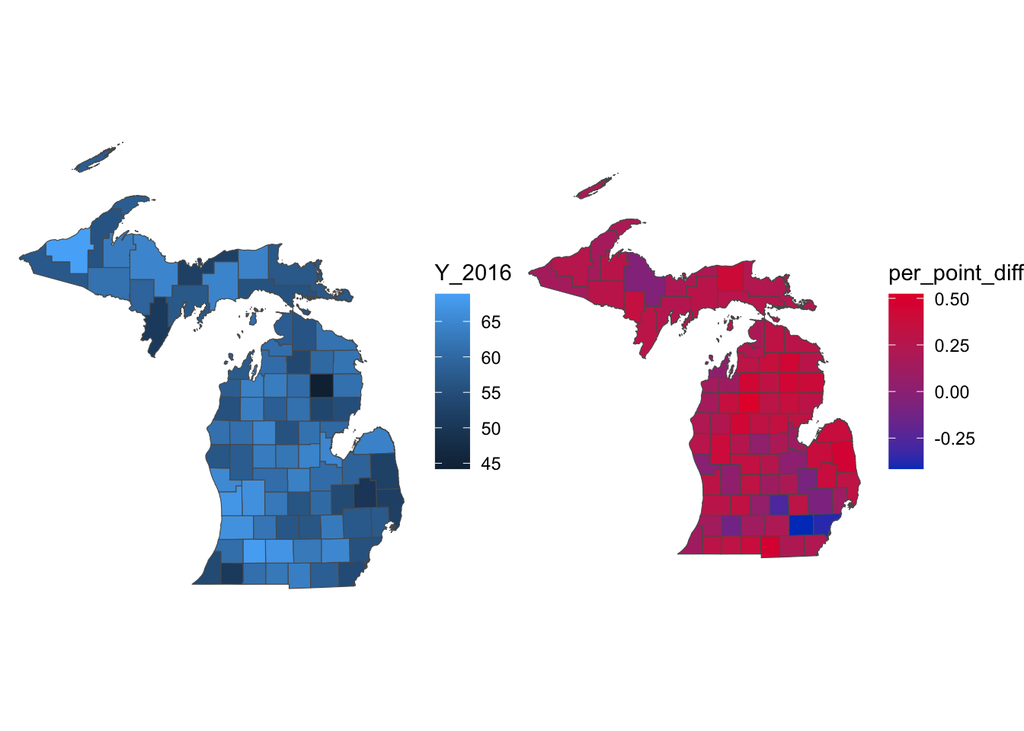

```r
vaccines_16 <- mi_counties %>%
  inner_join(vaccine_election_2016, by = c("name" = "cntyname")) %>%
  ggplot() +
  geom_sf(aes(fill = Y_2016)) +
  theme_void()

mi_election_map_16 <- mi_counties %>%
  inner_join(vaccine_election_2016, by = c("name" = "cntyname")) %>%
  ggplot() +
  geom_sf(aes(fill = per_point_diff)) +
  scale_fill_gradient(
    low = "#0041C2",
    high = "#e51d37"
  ) +
  theme_void()

grid.arrange(vaccines_16, mi_election_map_16, ncol = 2)
```

# Correlation coefficients

```r
# Correlation coefficients between the vaccine rates and the percentage point difference in that year's election. (GOP% - DEM%)
cor(vaccine_election_2020$Y_2020, vaccine_election_2020$per_point_diff)
```

```
## [1] -0.2070173
```

```r
cor(vaccine_election_2024$Y_2024, vaccine_election_2024$per_point_diff)
```

```
## [1] -0.2876186
```

```r
cor(vaccine_election_2016$Y_2016, vaccine_election_2016$per_point_diff)
```

```
## [1] -0.09219601
```

```r
# No significant results year by year.

# Percent change from 2020 to 2024 for both election result difference (pct points) and vaccine rates.
election_pct_change <- vaccine_election_2016 %>%
  inner_join(vaccine_election_2024, by=c("cntyname" = "cntyname")) %>%
  mutate(pct_change_election_points = 100 * (per_point_diff.y - per_point_diff.x)/per_point_diff.x) %>%
  select(cntyname, Y_2016, Y_2024, pct_change_election_points)

# Percent change over 10 years for aggregated vaccines (NOT USING!) and for election difference.
pct_change_vax_and_election <- pct_change_agg %>% inner_join(
  election_pct_change, by=c("cntyname" = "cntyname")
) %>%
  select(
    cntyname, pct_change_election_points, pct_change_2014_2024
  )

# Correlation between percent change in agg vaccine rates and percent change in election difference.
cor(pct_change_vax_and_election$pct_change_2014_2024, pct_change_vax_and_election$pct_change_election_points)
```

```
## [1] -0.05358504
```

```r
# There is no significant correlation between the percentage change in aggregated vaccination rates and the percentage change in the percentage point difference between the 2016 election and the 2024 election. I can't confidently compare the vaccination rates in a given county to how blue or red it voted in a given election.

# Correlation between percent change in infant vaccine rates and percent change in election difference.

# Join both percent change datasets together.
cc_baby_election <- baby_vax_change %>% inner_join(
  election_pct_change, by=c("cntyname" = "cntyname")
) %>%
  select(cntyname, pct_change_14_24, pct_change_election_points)

# Coefficient is -0.07. Little correlation.
cor(cc_baby_election$pct_change_14_24, cc_baby_election$pct_change_election_points)
```

```
## [1] -0.07368496
```

```r
# Same thing for teen vaccine series. Join both percentage change datasets together.
cc_teen_election <- teen_vax_change %>% inner_join(
  election_pct_change, by=c("cntyname" = "cntyname")
) %>%
  select(cntyname, pct_change_14_24, pct_change_election_points)

# Coefficient is -0.012. Little correlation.
cor(cc_teen_election$pct_change_14_24, cc_teen_election$pct_change_election_points)
```

```
## [1] -0.01242924
```

# MMR vaccine analysis from report card data (only 2024)

```r
# Let's look at MMR vaccination rates as of Dec. 31, 2024 (end of 2024 Q4)
report_card_data %>%
  filter(
    year == "2024",
    quarter == "Q4"
  ) %>%
  select(year, quarter, cntyname, covgmmr) %>%
  arrange(covgmmr) %>%
  slice(1:10)
```

```
##    year quarter  cntyname covgmmr
## 1  2024      Q4    Oscoda    52.8
## 2  2024      Q4  Keweenaw    56.5
## 3  2024      Q4   Gladwin    62.9
## 4  2024      Q4  Mackinac    66.9
## 5  2024      Q4   Sanilac    67.6
## 6  2024      Q4     Clare    67.9
## 7  2024      Q4   Osceola    69.2
## 8  2024      Q4  Houghton    69.3
## 9  2024      Q4 Hillsdale    70.1
## 10 2024      Q4    Branch    70.3
```

```r
report_card_data %>%
  filter(
    year == "2024",
    quarter == "Q3"
  ) %>%
  select(year, quarter, cntyname, covgmmr) %>%
  arrange(covgmmr) %>%
  slice(1:10)
```

```
##    year quarter cntyname covgmmr
## 1  2024      Q3   Oscoda    56.4
## 2  2024      Q3  Gladwin    61.5
## 3  2024      Q3 Keweenaw    61.9
## 4  2024      Q3  Sanilac    66.8
## 5  2024      Q3 Mackinac    67.5
## 6  2024      Q3    Clare    69.2
## 7  2024      Q3 Houghton    69.2
## 8  2024      Q3     Lake    69.7
## 9  2024      Q3  Osceola    70.6
## 10 2024      Q3   Branch    71.0
```

```r
report_card_data %>%
  filter(
    year == "2024",
    quarter == "Q2"
  ) %>%
  select(year, quarter, cntyname, covgmmr) %>%
  arrange(covgmmr) %>%
  slice(1:10)
```

```
##    year quarter cntyname covgmmr
## 1  2024      Q2 Keweenaw    57.8
## 2  2024      Q2  Gladwin    64.5
## 3  2024      Q2  Sanilac    66.9
## 4  2024      Q2 Mackinac    67.8
## 5  2024      Q2 Houghton    68.4
## 6  2024      Q2  Osceola    69.0
## 7  2024      Q2     Lake    70.6
## 8  2024      Q2    Clare    70.7
## 9  2024      Q2  Newaygo    71.4
## 10 2024      Q2    Iosco    72.2
```

```r
# Aggregating MMR vaccines by county


# Oscoda County had the lowest MMR vaccination rates, followed by Keweenaw, Gladwin, Mackinac and Salinac. None of these counties saw measles cases in 2025.
```

# Immunization status of children by school: 19-35 months.

# Questions

Write down questions you want answered:

# Potential sources:

Thrishika Bala, epidemiologist for the state of Michigan

Lynn Sutfin, PIO for Michigan DHHS, SutfinL1@michigan.gov

Ryan Malosh at MaloshR@michigan.gov

# Data Details

This website explains the different Series numbers for the sets of vaccines: https://www.michigan.gov/mdhhs/adult-child-serv/childrenfamilies/immunizations/data-statistics/countyimmsreportcards

Source: https://www.michigan.gov/mdhhs/adult-child-serv/childrenfamilies/immunizations/data-statistics/countyimmsreportcards

Documentation: https://www.michigan.gov/mdhhs/-/media/Project/Websites/mdhhs/Adult-and-Childrens-Services/Children-and-Families/Immunization-Information/LHD/Immunization-Report-Cards/Report_Card_Defs__FAQs_2021.pdf?rev=93e4ac10b66c4c10abcd3c02a6b55982&hash=EA6122E84CB516E9E6D335CC73BDB5CF